# R Notebook

# BEFORE YOU START

You’ll need to download the zip file from canvas and put it in the same working directory as this file. Make sure you unzip it and remove the contents so that you just have a data file and the PDF of the manuscript.

```r
library(tidyverse)
library(ggdist)
```

To read in the data, there are several files. We could have done this (should have done this?) the efficient way by creating a list, but instead we just loaded them in one by one.

```r
desc <- read_csv("data/desc_all.csv")
e2_error <- read_csv("data/e2_error_df.csv")
e5_error <- read_csv("data/e5_error_df.csv")
e15_error <- read_csv("data/e15_error_df.csv")
```

# Descriptives

This is the data that tells us how many groups each participant made and the language background of that participant. This is the data we need for that first box plot.

```r
# trying to know what code is. It seems to be a number version of group name
desc %>%
  distinct(Code, group_name)
```

| Code | group_name |
| --- | --- |
| 100 | eng_mono |
| 112 | south_asian |
| 101 | non_asian_multi |
| 111 | east_asian |
| 113 | se_asian |
| NA | NA |

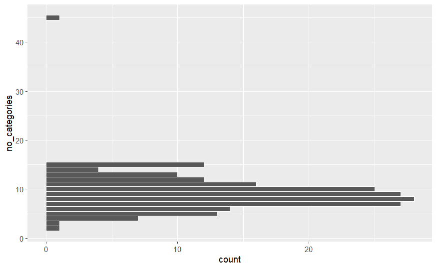

```r
desc %>%
  ggplot(aes(y = no_categories)) +
  geom_histogram(binwidth = 1,
                 color = "white")
```

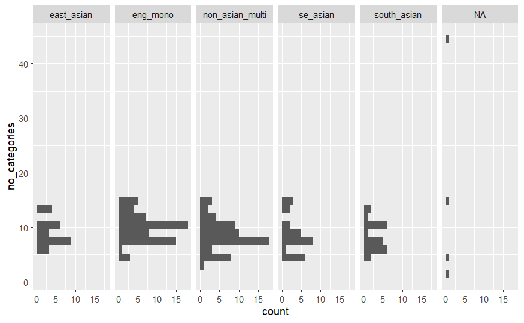

```r
desc %>%
  ggplot(aes(y = no_categories)) +
  geom_histogram() +
  facet_grid(~group_name)
```

We noticed that there’s an NA - let’s make sure that’s “missing” and not the letters “NA”

```r
desc %>%
  distinct(group_name)
```

| group_name |
| --- |
| eng_mono |
| south_asian |
| non_asian_multi |
| east_asian |
| se_asian |
| NA |

We also noticed that there seems to be a larger sample (i.e., more overall counts) for the engligh mono and non-asian multi groups. Let’s see if that’s true/what the sample sizes are

```r
desc %>%
  count(group_name)
```

| group_name | n |
| --- | --- |
| east_asian | 25 |
| eng_mono | 61 |
| non_asian_multi | 58 |
| se_asian | 27 |
| south_asian | 23 |
| NA | 4 |

## Plot number 1

```r
grouped_cat_desc <- desc %>%
  group_by(group_name) %>%
  summarise(mean = mean(no_categories),
            sd = sd(no_categories)) %>%
  mutate(mean_sd = str_c(round(mean, 2), " (", round(sd, 2), ")"))
```

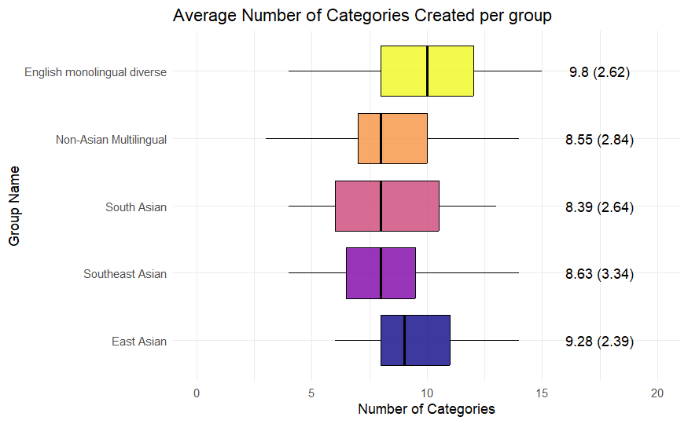

```r
desc %>%
  filter(is.na(group_name) == FALSE) %>%
  mutate(full_group_name = case_when(group_name == "south_asian" ~ "South Asian",
                                     group_name == "se_asian" ~ "Southeast Asian",
                                     group_name == "non_asian_multi" ~ "Non-Asian Multilingual",
                                     group_name == "eng_mono" ~ "English monolingual diverse",
                                     group_name == "east_asian" ~ "East Asian"),
         full_group_name = factor(full_group_name,
                                  levels = c("English monolingual diverse",
                                             "Non-Asian Multilingual",
                                             "South Asian",
                                             "Southeast Asian",
                                             "East Asian"))) %>%
  ggplot(aes(y = fct_rev(full_group_name),
             x = no_categories,
             fill = fct_rev(full_group_name))) +
  geom_boxplot(color = "black",
               outliers = FALSE,
               alpha = 0.8) +
  xlim(0, 20) +
  labs(x = "Number of Categories",
       y = "Group Name",
       title = "Average Number of Categories Created per group") +
  theme_minimal() +
  theme(legend.position = "none") +
  scale_fill_viridis_d(option = "plasma") +
  annotate(geom = "text", y = 1, x = 17.5, label = filter(grouped_cat_desc, group_name == "east_asian")$mean_sd) +
  annotate(geom = "text", y = 2, x = 17.5, label = filter(grouped_cat_desc, group_name == "se_asian")$mean_sd) +
  annotate(geom = "text", y = 3, x = 17.5, label = filter(grouped_cat_desc, group_name == "south_asian")$mean_sd) +
  annotate(geom = "text", y = 4, x = 17.5, label = filter(grouped_cat_desc, group_name == "non_asian_multi")$mean_sd) +
  annotate(geom = "text", y = 5, x = 17.5, label = filter(grouped_cat_desc, group_name == "eng_mono")$mean_sd)
```

# Plot 2

```r
desc
```

| ...1 | X | no_categories | Participant | Code | group_name |
| --- | --- | --- | --- | --- | --- |
| 1 | 1 | 11 | 8 | 100 | eng_mono |
| 2 | 2 | 6 | 7 | 112 | south_asian |
| 3 | 3 | 6 | 1 | 101 | non_asian_multi |
| 4 | 4 | 13 | 9 | 100 | eng_mono |
| 5 | 5 | 7 | 10 | 100 | eng_mono |
| 6 | 6 | 15 | 11 | 100 | eng_mono |
| 7 | 7 | 4 | 12 | 101 | non_asian_multi |
| 8 | 8 | 10 | 13 | 100 | eng_mono |
| 9 | 9 | 12 | 14 | 100 | eng_mono |
| 10 | 10 | 12 | 15 | 100 | eng_mono |

[output cut: 188 more lines]